# Homework 3

## Part 2: Let’s use the data

1. Using `covid.usa.daily` select *3 highly impacted states*, *3 mildly impacted states* by COVID-19, where by ‘highly impacted’ I mean the states with high numbers of confirmed cases.

###3 Highly Impacted States: California, Florida, and New York

```r
#selecting 3 highly impacted states: California, Florida, and New York

covid.usa.daily %>%
  filter(Province_State == "California" | Province_State == "Florida" | Province_State == "New York") %>%
  select(Province_State, Confirmed, Deaths)
```

```
## # A tibble: 3 x 3
##   Province_State Confirmed Deaths
##   <chr>              <dbl>  <dbl>
## 1 California       9498696  91057
## 2 Florida          6101783  74374
## 3 New York         5380498  68830
```

###3 Midly Impacted States: Hawaii, Oregon, and Rhode Island

```r
#selecting 3 mildly impacted states: Hawaii, Oregon, and Rhode Island

covid.usa.daily %>%
  filter(Province_State == "Hawaii" | Province_State == "Oregon" | Province_State == "Rhode Island") %>%
  select(Province_State, Confirmed, Deaths)
```

```
## # A tibble: 3 x 3
##   Province_State Confirmed Deaths
##   <chr>              <dbl>  <dbl>
## 1 Hawaii            265571   1446
## 2 Oregon            753575   7591
## 3 Rhode Island      388586   3562
```

3. Create a visualization of the evolution of confirmed cases, deaths, and people vaccinated for each of the 6 states identified as *highly* and *mildly* impacted (use the `covid.usa.states.ts` data.frame to create the figure).  
   #3 Highly Impacted States: California, Florida, and New York

##California

###Covid Cases Plot:

```r
#filtering only data for California from the covid.usa.states.vacc.joined.ts data set
covid.california <- covid.usa.states.vacc.joined.ts %>%
  filter(Province_State == "California")
#actual size: 518x11
head(covid.california)
```

```
## # A tibble: 6 x 11
##    FIPS Province_State Country_Region date_col     Lat Long_ Combined_Key
##   <dbl> <chr>          <chr>          <date>     <dbl> <dbl> <chr>
## 1     6 California     US             2021-01-01  36.1 -120. California, US
## 2     6 California     US             2021-01-02  36.1 -120. California, US
## 3     6 California     US             2021-01-03  36.1 -120. California, US
## 4     6 California     US             2021-01-04  36.1 -120. California, US
## 5     6 California     US             2021-01-05  36.1 -120. California, US
## 6     6 California     US             2021-01-06  36.1 -120. California, US
## # ... with 4 more variables: People_Fully_Vaccinated <dbl>,
## #   People_Partially_Vaccinated <dbl>, total_cases <dbl>, total_deaths <dbl>
```

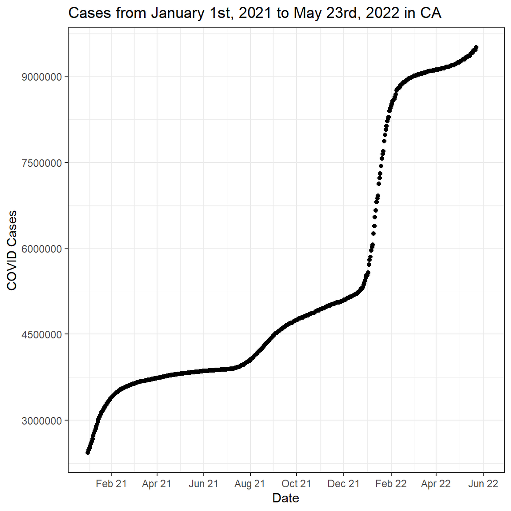

```r
#changing from scientific notation to regular numbers
options(scipen=10000)

#plotting total covid cases from January 1st, 2021 to May 23rd, 2022 for California
covid.california.cases.plot <- ggplot(data = covid.california, aes(x = date_col, y = total_cases)) +
  geom_point(na.rm=TRUE) +
  ggtitle("Cases from January 1st, 2021 to May 23rd, 2022 in CA") +
  xlab("Date")+
  ylab("COVID Cases") +
  (scale_x_date(breaks = date_breaks("2 months"),
                labels = date_format("%b %y"))) +
  scale_y_continuous(breaks = seq(0, 10000000, 1500000)) +
  theme_bw()
covid.california.cases.plot
```

###Covid Deaths Plot:

```r
#filtering only data for California from the covid.usa.states.vacc.joined.ts data set
covid.california <- covid.usa.states.vacc.joined.ts %>%
  filter(Province_State == "California")
#actual size: 518x11
head(covid.california)
```

```
## # A tibble: 6 x 11
##    FIPS Province_State Country_Region date_col     Lat Long_ Combined_Key
##   <dbl> <chr>          <chr>          <date>     <dbl> <dbl> <chr>
## 1     6 California     US             2021-01-01  36.1 -120. California, US
## 2     6 California     US             2021-01-02  36.1 -120. California, US
## 3     6 California     US             2021-01-03  36.1 -120. California, US
## 4     6 California     US             2021-01-04  36.1 -120. California, US
## 5     6 California     US             2021-01-05  36.1 -120. California, US
## 6     6 California     US             2021-01-06  36.1 -120. California, US
## # ... with 4 more variables: People_Fully_Vaccinated <dbl>,
## #   People_Partially_Vaccinated <dbl>, total_cases <dbl>, total_deaths <dbl>
```

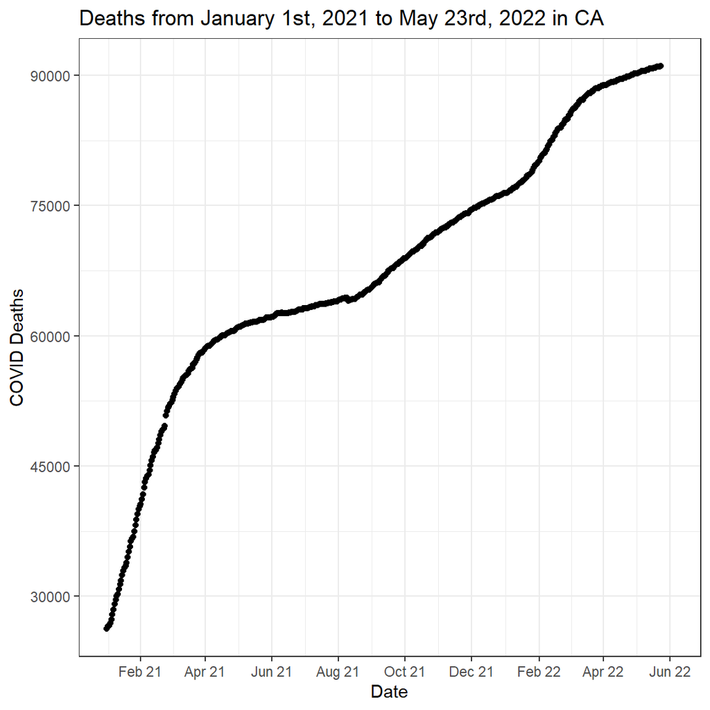

```r
#changing from scientific notation to regular numbers
options(scipen=10000)

#plotting total covid deaths from January 1st, 2021 to May 23rd, 2022 for California
covid.california.deaths.plot <- ggplot(data = covid.california, aes(x = date_col, y = total_deaths)) +
  geom_point(na.rm=TRUE) +
  ggtitle("Deaths from January 1st, 2021 to May 23rd, 2022 in CA") +
  xlab("Date")+
  ylab("COVID Deaths") +
  (scale_x_date(breaks = date_breaks("2 months"),
                labels = date_format("%b %y"))) +
  scale_y_continuous(breaks = seq(0, 92000, 15000)) +
  theme_bw()
covid.california.deaths.plot
```

###Covid Vaccinations Plot:

```r
#filtering only data for California from the covid.usa.states.vacc.joined.ts data set
covid.california <- covid.usa.states.vacc.joined.ts %>%
  filter(Province_State == "California")
#actual size: 518x11
head(covid.california)
```

```
## # A tibble: 6 x 11
##    FIPS Province_State Country_Region date_col     Lat Long_ Combined_Key
##   <dbl> <chr>          <chr>          <date>     <dbl> <dbl> <chr>
## 1     6 California     US             2021-01-01  36.1 -120. California, US
## 2     6 California     US             2021-01-02  36.1 -120. California, US
## 3     6 California     US             2021-01-03  36.1 -120. California, US
## 4     6 California     US             2021-01-04  36.1 -120. California, US
## 5     6 California     US             2021-01-05  36.1 -120. California, US
## 6     6 California     US             2021-01-06  36.1 -120. California, US
## # ... with 4 more variables: People_Fully_Vaccinated <dbl>,
## #   People_Partially_Vaccinated <dbl>, total_cases <dbl>, total_deaths <dbl>
```

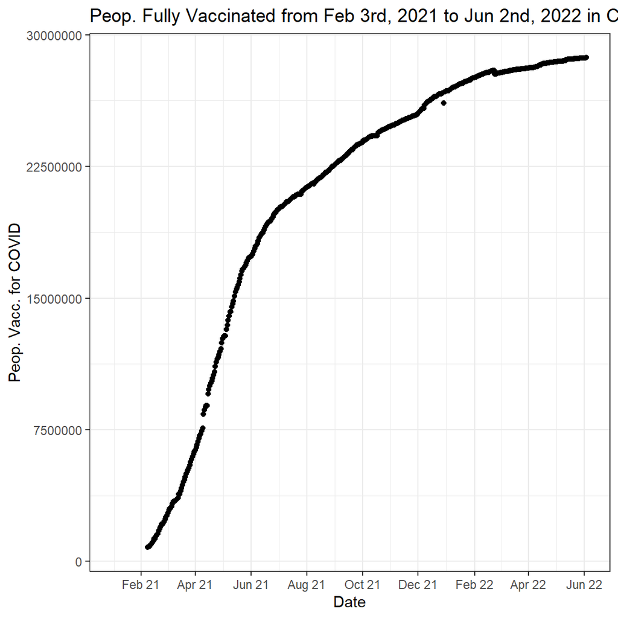

```r
#changing from scientific notation to regular numbers
options(scipen=10000)

#plotting total people vaccinated from Feburary 3rd, 2021 to June 2nd, 2022 in California
covid.california.vacc.plot <- ggplot(data = covid.california, aes(x = date_col, y = People_Fully_Vaccinated)) +
  geom_point(na.rm=TRUE) +
  ggtitle("Peop. Fully Vaccinated from Feb 3rd, 2021 to Jun 2nd, 2022 in CA") +
  xlab("Date")+
  ylab("Peop. Vacc. for COVID") +
  (scale_x_date(breaks = date_breaks("2 months"),
                labels = date_format("%b %y"))) +
  scale_y_continuous(breaks = seq(0, 30000000, 7500000)) +
  theme_bw()
covid.california.vacc.plot
```

###All Three Plots Together:

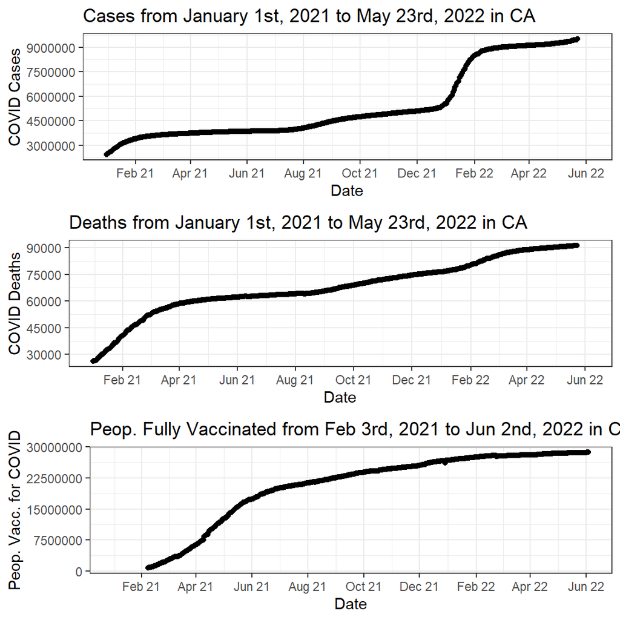

```r
#arranging plots that show cases, deaths, and vaccinations next to each other for Hawaii
require(gridExtra)
grid.arrange(covid.california.cases.plot, covid.california.deaths.plot, covid.california.vacc.plot, heights=c(1,1,1))
```

##Florida

###Covid Cases Plot:

```r
#filtering only data for Florida from the covid.usa.states.vacc.joined.ts data set
covid.florida <- covid.usa.states.vacc.joined.ts %>%
  filter(Province_State == "Florida")
#actual size: 518x11
head(covid.florida)
```

```
## # A tibble: 6 x 11
##    FIPS Province_State Country_Region date_col     Lat Long_ Combined_Key
##   <dbl> <chr>          <chr>          <date>     <dbl> <dbl> <chr>
## 1    12 Florida        US             2021-01-01  27.8 -81.7 Florida, US
## 2    12 Florida        US             2021-01-02  27.8 -81.7 Florida, US
## 3    12 Florida        US             2021-01-03  27.8 -81.7 Florida, US
## 4    12 Florida        US             2021-01-04  27.8 -81.7 Florida, US
## 5    12 Florida        US             2021-01-05  27.8 -81.7 Florida, US
## 6    12 Florida        US             2021-01-06  27.8 -81.7 Florida, US
## # ... with 4 more variables: People_Fully_Vaccinated <dbl>,
## #   People_Partially_Vaccinated <dbl>, total_cases <dbl>, total_deaths <dbl>
```

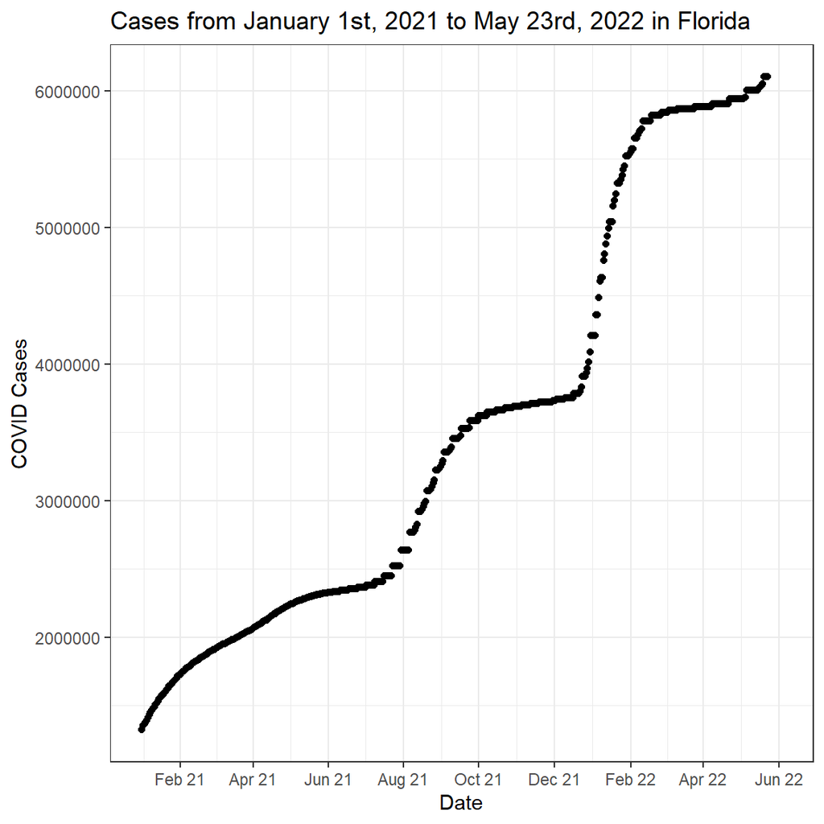

```r
#changing from scientific notation to regular numbers
options(scipen=10000)

#plotting total covid cases from January 1st, 2021 to May 23rd, 2022 for Florida
covid.florida.cases.plot <- ggplot(data = covid.florida, aes(x = date_col, y = total_cases)) +
  geom_point(na.rm=TRUE) +
  ggtitle("Cases from January 1st, 2021 to May 23rd, 2022 in Florida") +
  xlab("Date")+
  ylab("COVID Cases") +
  (scale_x_date(breaks = date_breaks("2 months"),
                labels = date_format("%b %y"))) +
  scale_y_continuous(breaks = seq(0, 6500000, 1000000)) +
  theme_bw()
covid.florida.cases.plot
```

###Covid Deaths Plot:

```r
#filtering only data for Florida from the covid.usa.states.vacc.joined.ts data set
covid.florida <- covid.usa.states.vacc.joined.ts %>%
  filter(Province_State == "Florida")
#actual size: 518x11
head(covid.florida)
```

```
## # A tibble: 6 x 11
##    FIPS Province_State Country_Region date_col     Lat Long_ Combined_Key
##   <dbl> <chr>          <chr>          <date>     <dbl> <dbl> <chr>
## 1    12 Florida        US             2021-01-01  27.8 -81.7 Florida, US
## 2    12 Florida        US             2021-01-02  27.8 -81.7 Florida, US
## 3    12 Florida        US             2021-01-03  27.8 -81.7 Florida, US
## 4    12 Florida        US             2021-01-04  27.8 -81.7 Florida, US
## 5    12 Florida        US             2021-01-05  27.8 -81.7 Florida, US
## 6    12 Florida        US             2021-01-06  27.8 -81.7 Florida, US
## # ... with 4 more variables: People_Fully_Vaccinated <dbl>,
## #   People_Partially_Vaccinated <dbl>, total_cases <dbl>, total_deaths <dbl>
```

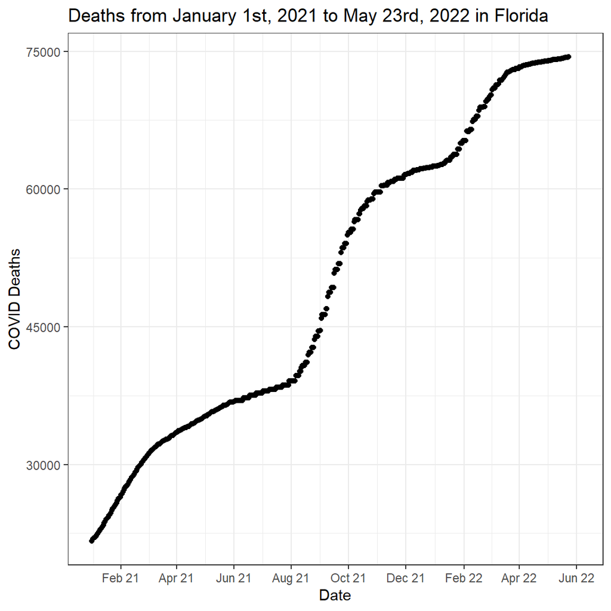

```r
#changing from scientific notation to regular numbers
options(scipen=10000)

#plotting total covid deaths from January 1st, 2021 to May 23rd, 2022 for Florida
covid.florida.deaths.plot <- ggplot(data = covid.florida, aes(x = date_col, y = total_deaths)) +
  geom_point(na.rm=TRUE) +
  ggtitle("Deaths from January 1st, 2021 to May 23rd, 2022 in Florida") +
  xlab("Date")+
  ylab("COVID Deaths") +
  (scale_x_date(breaks = date_breaks("2 months"),
                labels = date_format("%b %y"))) +
  scale_y_continuous(breaks = seq(0, 75000, 15000)) +
  theme_bw()
covid.florida.deaths.plot
```

###Covid Vaccinations Plot:

```r
#filtering only data for Florida from the covid.usa.states.vacc.joined.ts data set
covid.florida <- covid.usa.states.vacc.joined.ts %>%
  filter(Province_State == "Florida")
#actual size: 518x11
head(covid.florida)
```

```
## # A tibble: 6 x 11
##    FIPS Province_State Country_Region date_col     Lat Long_ Combined_Key
##   <dbl> <chr>          <chr>          <date>     <dbl> <dbl> <chr>
## 1    12 Florida        US             2021-01-01  27.8 -81.7 Florida, US
## 2    12 Florida        US             2021-01-02  27.8 -81.7 Florida, US
## 3    12 Florida        US             2021-01-03  27.8 -81.7 Florida, US
## 4    12 Florida        US             2021-01-04  27.8 -81.7 Florida, US
## 5    12 Florida        US             2021-01-05  27.8 -81.7 Florida, US
## 6    12 Florida        US             2021-01-06  27.8 -81.7 Florida, US
## # ... with 4 more variables: People_Fully_Vaccinated <dbl>,
## #   People_Partially_Vaccinated <dbl>, total_cases <dbl>, total_deaths <dbl>
```

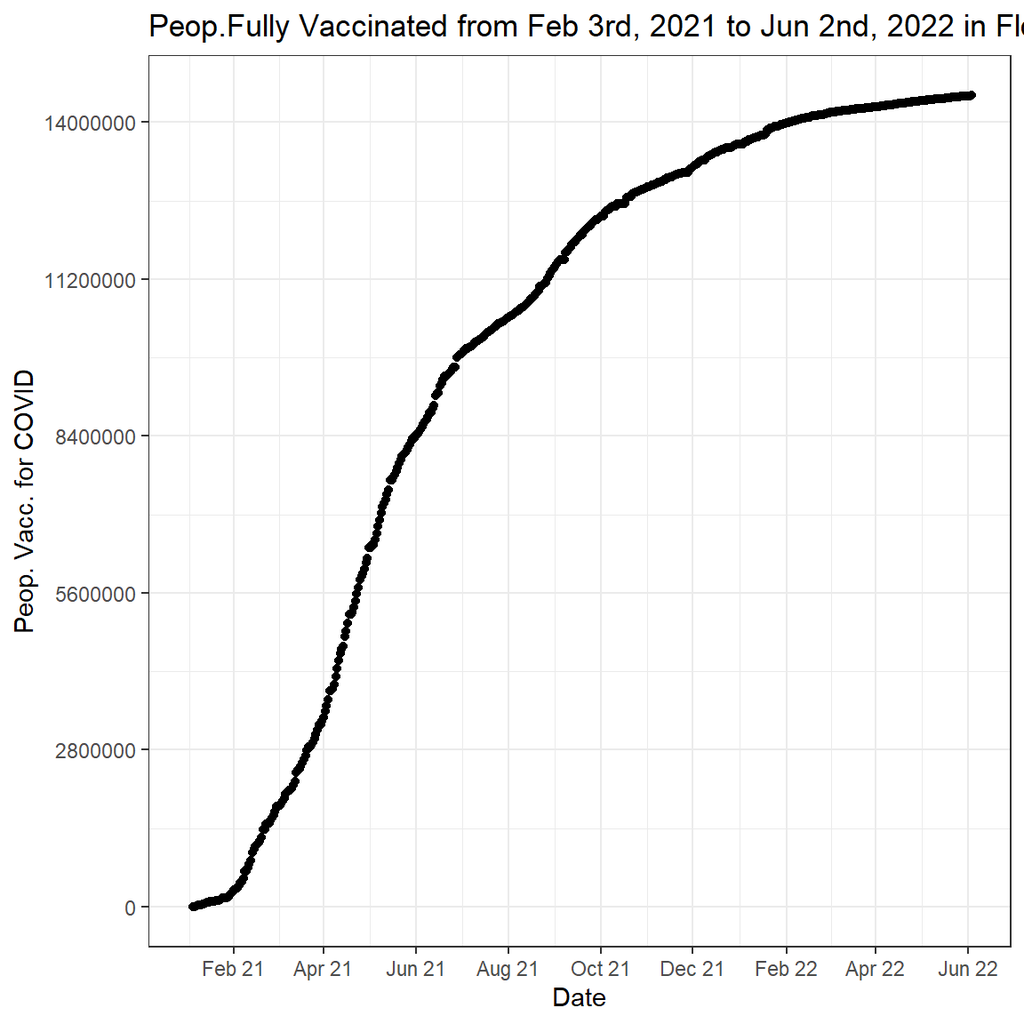

```r
#changing from scientific notation to regular numbers
options(scipen=10000)

#plotting total people vaccinated from Feburary 3rd, 2021 to June 2nd, 2022 in Florida
covid.florida.vacc.plot <- ggplot(data = covid.florida, aes(x = date_col, y = People_Fully_Vaccinated)) +
  geom_point(na.rm=TRUE) +
  ggtitle("Peop.Fully Vaccinated from Feb 3rd, 2021 to Jun 2nd, 2022 in Florida") +
  xlab("Date")+
  ylab("Peop. Vacc. for COVID") +
  (scale_x_date(breaks = date_breaks("2 months"),
                labels = date_format("%b %y"))) +
  scale_y_continuous(breaks = seq(0, 15000000, 2800000)) +
  theme_bw()
covid.florida.vacc.plot
```

###All Three Plots Together:

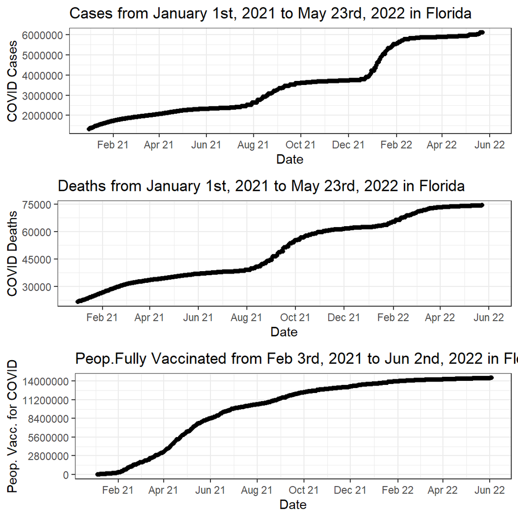

```r
#arranging plots that show cases, deaths, and vaccinations next to each other for Hawaii
require(gridExtra)
grid.arrange(covid.florida.cases.plot, covid.florida.deaths.plot, covid.florida.vacc.plot, heights=c(1,1,1))
```

##New York